# act_report

## About the dataset (twitter_archive_master) and findings

> It is no doubt that even our master dataset requires further wrangling. For example, we most likely still have few invalid ratings, incorrect dog stages and so on. Though these outliers seem minimal, they might significantly affect our analysis if not 'ultimately' cleaned. However, we analyzed based on retweet count, favorite count, month and year because they are accurate (no retweets).

> From a simple descriptive analysis of retweet count and favorite count, a fact we noticed is that from November 2015 to August 2017, the ‘mean number of tweets’ decreases significantly while the number of retweets increases (though decreases at intervals). Same applies to ‘mean number of liked tweets’ but the only difference is that drop intervals are small compared to ‘mean number of retweets’.

> Also, 6 of the top 100 liked tweets was posted in 2015, 25 in 2016 and 69 in 2017

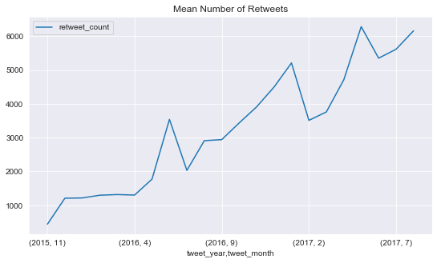

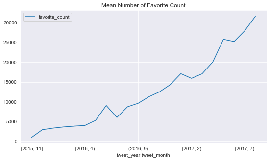

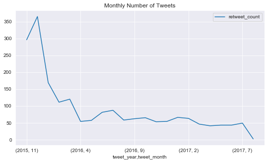

## Future improvement

> It would really be nice if we could find patterns in tweets with high number of retweets and likes. Also, a lot of insights can be drawn from the ratings column. In simple terms, a future improvement would be 'further wrangling'.